# Ejemplo de votaciones

Luis Fernando Apáez Álvarez

27/10/2021

Problema 1

Problema 2

`VPH_CEL` contra VXM

`P15YM_ANSEIN` contra VXM

Ejercicio 1

`VPH_CEL` contra JHH

Ejercicio 2

Problema 3

Ejercicio 3

Problema 4

Ejercicio 4

# Análisis descriptivo

Comenzamos por cargar los datos

```r
diputaciones <- read.csv('diputaciones.csv')
distritos <- read.csv('PORCENTAJES_INE_DISTRITO_2020.csv')
```

donde * `diputaciones`: continen los resultados de la votación por acta a nivel Federal. * `distritos`: es la base de datos que hemos venido trabajado.

## Problema 1

Calcular porcentajes a favor de cierto partido o coalicíon, por ejemplo, Morena para cada distrito electoral (si es una coalicíon, se deben sumar varias columna, donde las coaliciones son *va por México (vxm)* y *Juntos haremos historia (jhh)*).

**Solución:** Comenzaremos por hallar el porcentaje a favor de los partidos individualmente. Recordemos que el porcentaje de un cierto número de datos se calcula como

$$\frac{(\textrm{ciertos datos})\times 100}{\textrm{total de datos}}$$
por lo que

```r
# Calculamos el total de votos
total_votos<-sum(diputaciones$TOTAL_VOTOS_CALCULADOS)

distritos$PAN<-diputaciones$PAN/ total_votos * 100
distritos$PRI<-diputaciones$PRI/ total_votos * 100
distritos$PRD<-diputaciones$PRD/ total_votos * 100
distritos$PVEM<-diputaciones$PVEM/ total_votos * 100
distritos$PT<-diputaciones$PT/ total_votos * 100
distritos$MC<-diputaciones$MC/ total_votos * 100
distritos$MORENA<-diputaciones$MORENA/ total_votos * 100
distritos$PES<-diputaciones$PES/ total_votos * 100
distritos$RSP<-diputaciones$RSP/ total_votos * 100
distritos$FXM<-diputaciones$FXM/ total_votos * 100
distritos$CI<-diputaciones$CI/ total_votos * 100
```

donde

- PAN - Número de votos para el Partido Acción Nacional
- PRI - Número de votos para el Partido Revolucionario Institucional
- PRD - Número de votos para el Partido de la Revolución Democrática
- PVEM - Número de votos para el Partido Verde Ecologista de México
- PT - Número de votos para el Partido del Trabajo
- MOVIMIENTO CIUDADANO- Número de votos para el Partido Movimiento Ciudadano
- MORENA - Número de votos para el Partido Morena
- PES - Número de votos para el Partido Encuentro Solidario
- RSP - Número de votos para el Partido Redes Sociales Progresistas
- FXM - Número de votos para el Partido Fuerza Por México
- CI - Número de votos para la candidatura independiente

Después proseguimos a los porcentajes de las coaliciones

```r
distritos$VXM<-(diputaciones$PAN + diputaciones$PRI + diputaciones$PRD + diputaciones$PAN.PRI.PRD + diputaciones$PAN.PRI + diputaciones$PAN.PRD + diputaciones$PRI.PRD) / total_votos * 100
distritos$JHH<-(diputaciones$MORENA + diputaciones$PT + diputaciones$PVEM + diputaciones$PVEM.PT.MORENA + diputaciones$PVEM.PT + diputaciones$PVEM.MORENA + diputaciones$PT.MORENA) / total_votos * 100
```

Finalmente sobre los votos nulos y los candidatos no registrados

```r
distritos$VOTOSNULOS<-diputaciones$VOTOS.NULOS / total_votos * 100
distritos$CNR <- diputaciones$CANDIDATO.A.NO.REGISTRADO.A / total_votos * 100
```

## Problema 2

Generar diagramas de dispersíon entre la variable construida en 1) con cada una de las 5 variables construidas en clase sobre estad́ısticas censales a escalas geoelectorales. Esto es

- (VPH_CEL) % Viviendas particulares habitadas que disponen de teléfono celular
- (VPH_EXCSA) % Viviendas particulares habitadas que disponen de excusado o sanitario
- (PSINDER) % Población sin afiliación a servicios de salud
- (HOGJEF_F) % Hogares censales con persona de referencia mujer
- (P15yM_ANSEIN)% Poblacion de 15 años y más analfabeta, sin escolaridad y con primaria incompleta

Finalmente, interprete.

**Solución:** Compararemos cada una de las variables anteriores respecto a las coaliciones, donde además se mostrará individualemnte la comparación entre la variable de interés con cada partido de dicha coalición. Para ello

### `VPH_CEL` contra VXM

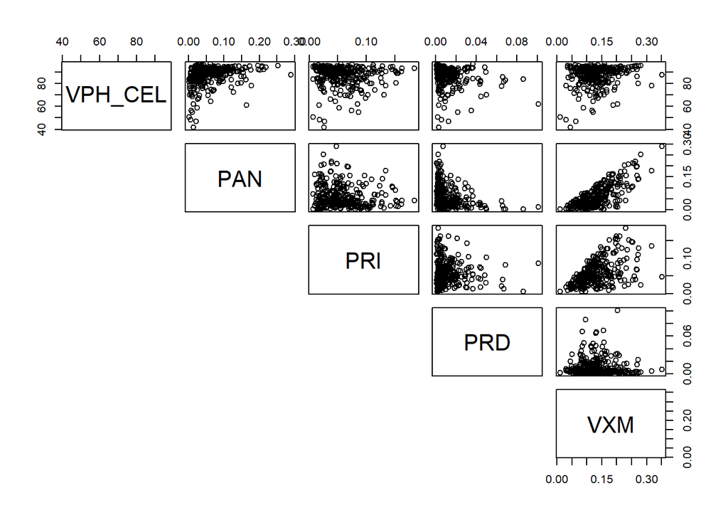

```r
pairs(~VPH_CEL + PAN + PRI + PRD + VXM , data= distritos , lower.panel = NULL)
```

Para la interpretación bastará con tomar de ejemplo un sólo gráfico de dispersión. En nuestro caso tomaremos el siguiente:

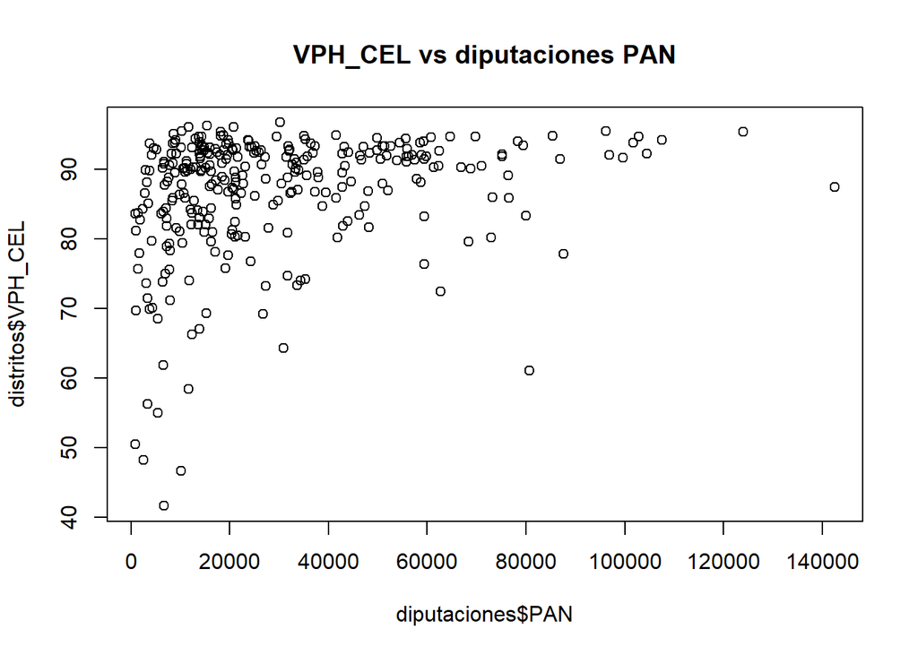

```r
plot(diputaciones$PAN, distritos$VPH_CEL, pch=21,
     main = 'VPH_CEL vs diputaciones PAN' )
```

podemos decir que la mayoría del porcentaje de votación por el PAN mantiene constante el porcentaje de celulares por vivienda entre el 70% y 100%. De la misma forma podría realizarse la interpretación de la variable `VPH_CEL` con respecto al porcentaje de votación del resto de partidos de la coalición.

### `P15YM_ANSEIN` contra VXM

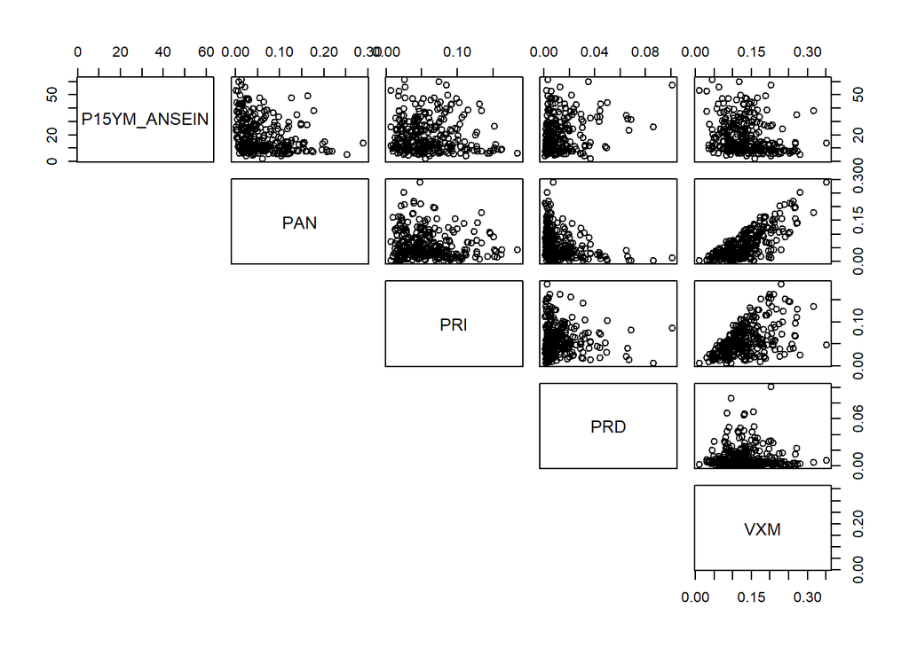

```r
pairs(~P15YM_ANSEIN + PAN + PRI + PRD + VXM , data= distritos , lower.panel = NULL)
```

Para la interpretación bastará con tomar de ejemplo un sólo gráfico de dispersión. En nuestro caso volveremos a realizar la interpretación de contrastar `P15YM_ANSEIN` contra PAN

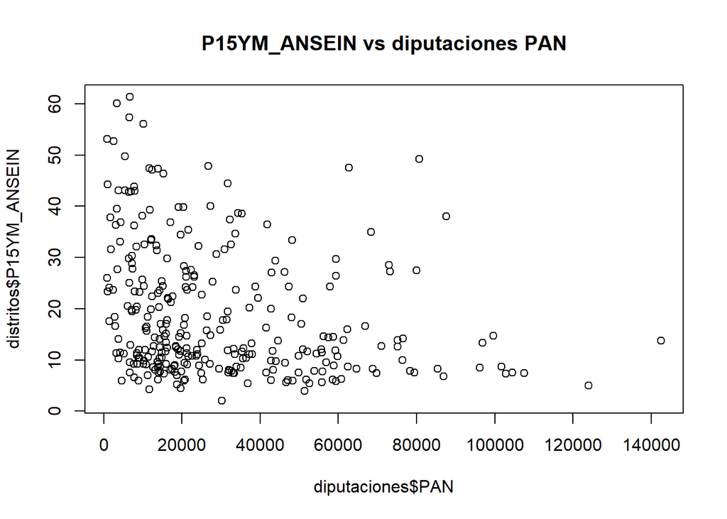

```r
plot(diputaciones$PAN, distritos$P15YM_ANSEIN, pch=21,
     main = 'P15YM_ANSEIN vs diputaciones PAN' )
```

en el cual puede decirse que el porcentaje de votaciones por el PAN mantiene un porcentaje de personas mayores a 15 y más analfábeta entre el 0% y el 40% (en su mayoría).

### Ejercicio 1

Termina el código para el contraste entre las variables `VPH_EXCSA`, `PSINDER` y `HOGJEF_F` y la coalición VXM. Además, toma individualmente un diagrama de dispersión como se ha hecho anteriormente e interpreta.

### `VPH_CEL` contra JHH

Continuamos realizando el análisis de las 5 variables contra la coalición *Juntos haremos historia*. Sólo graficaremos los diagramas de `VPH_CEL` contra JHH y nos concentraremos en particular en `VPH_CEL` contra MORENA.

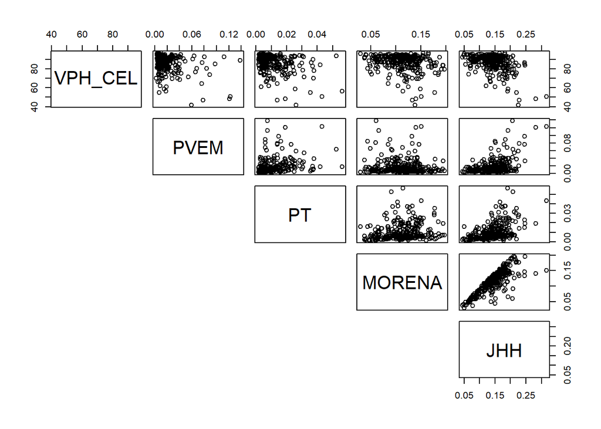

```r
pairs(~VPH_CEL + PVEM + PT +  MORENA + JHH  , data= distritos , lower.panel = NULL)
```

Y en particular tomamos

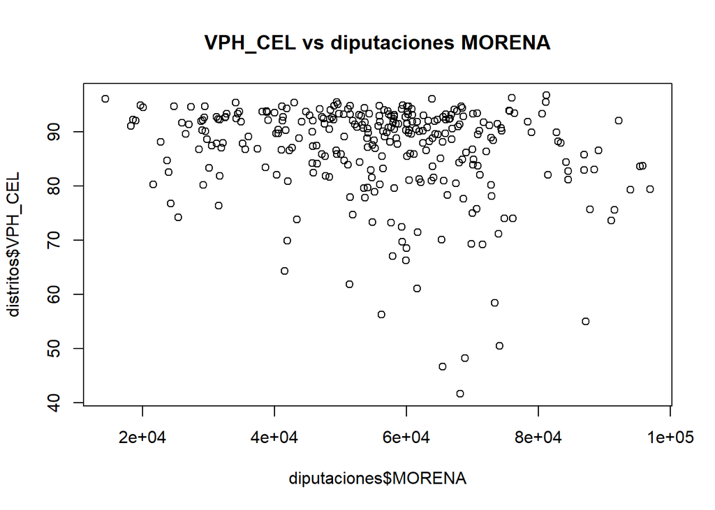

```r
plot(diputaciones$MORENA, distritos$VPH_CEL, pch=21,
     main = 'VPH_CEL vs diputaciones MORENA' )
```

del cual podemos decir que el porcentaje de votación por MORENA mantiene constante el porcentaje de celulares por vivienda entre el 70% y el 100%.

### Ejercicio 2

1. Gráfica los diagramas de dispersión del resto de las variables contra la coalición JHH (deberás utilizar el comando `pairs`).
2. De los diagramas graficados anteriormente toma un diagrama de dispersión en particular e interpreta.
3. Gráfica los diagramas de dispersión de las 5 variables contra la coalición de los partidos MC, PES, RSP y FXM. Toma un diagrama de dispersión individual e interpreta.
4. Gráfica los diagramas de dispersión de las 5 variables contra el porcentaje de votos para candidaturas indpendientes (CI), votos nulos (VOTOSNULOS) y candidatos no registrados (CNR). Toma un diagrama de dispersión individual e interpreta.

## Problema 3

Generar un ańalisis descriptivo de la variable construida en 1) por circunscripcíon. Interprete.

**Solución:**

Ocuparemos nuevamente un vector de colores para identificar a las circunscripciones

```r
color<- c('#DDA0DD', "#6A5ACD", "#708090", '#800000','#DA70D6' )
```

Luego

```r
summary(distritos$PAN)
```

```
##     Min.  1st Qu.   Median     Mean  3rd Qu.     Max.
## 0.001715 0.023664 0.042404 0.060032 0.087088 0.289960
```

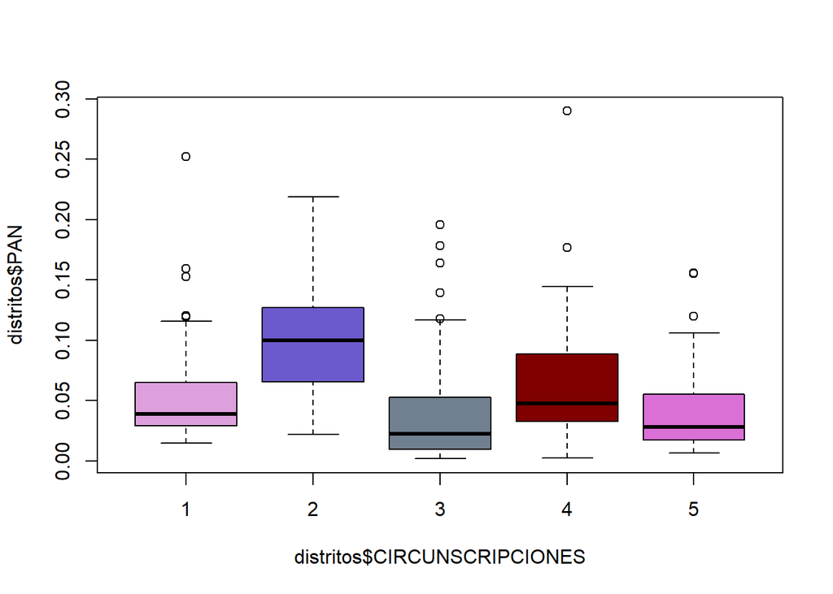

```r
boxplot(distritos$PAN ~ distritos$CIRCUNSCRIPCIONES, col= color )
```

Procedemos después al análisis de los votos por MORENA por circunscripción

```r
summary(distritos$MORENA)
```

```
##    Min. 1st Qu.  Median    Mean 3rd Qu.    Max.
## 0.02914 0.09274 0.11633 0.11318 0.13526 0.19723
```

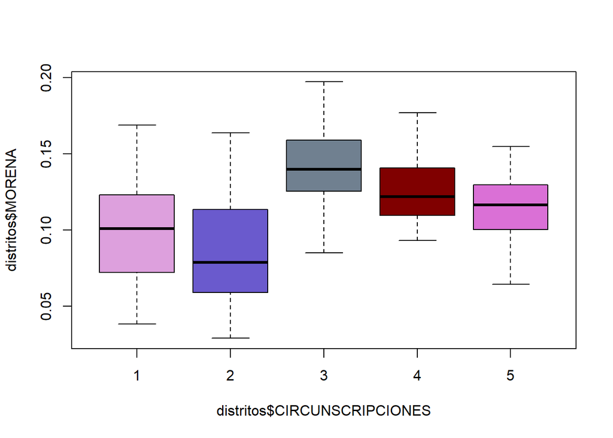

```r
boxplot(distritos$MORENA ~ distritos$CIRCUNSCRIPCIONES, col= color )
```

Finalemnte analicemos el contraste entre las coaliciones VXM y JHH por circunscripción. Primero

```r
# VXM
summary(distritos$VXM)
```

```
##    Min. 1st Qu.  Median    Mean 3rd Qu.    Max.
## 0.01051 0.09063 0.12546 0.13209 0.16282 0.35140
```

```r
# JHH
summary(distritos$JHH)
```

```
##    Min. 1st Qu.  Median    Mean 3rd Qu.    Max.
## 0.04476 0.11898 0.14145 0.14259 0.16819 0.31651
```

Para VXM

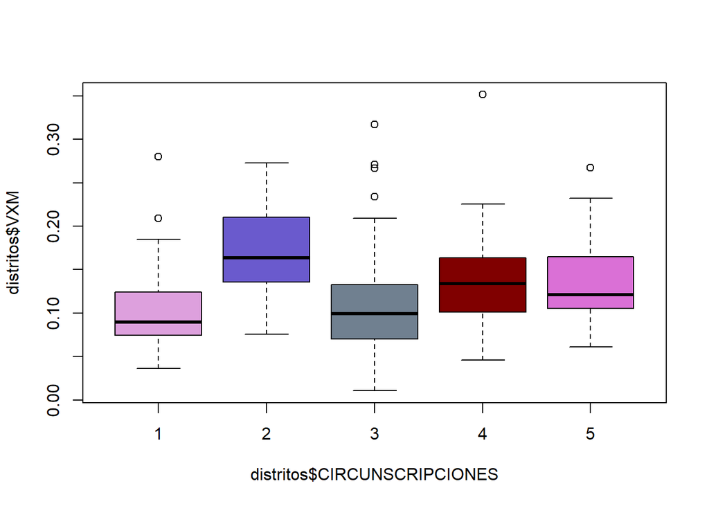

```r
boxplot(distritos$VXM ~ distritos$CIRCUNSCRIPCIONES, col= color )
```

Para JHH

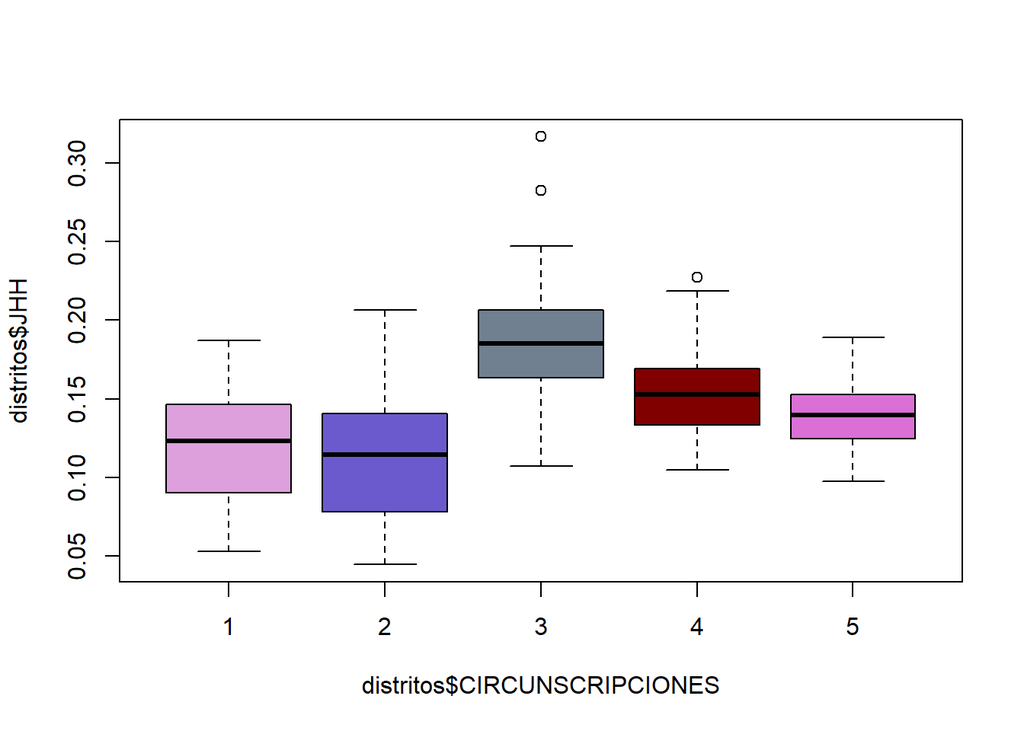

```r
boxplot(distritos$JHH ~ distritos$CIRCUNSCRIPCIONES, col= color )
```

### Ejercicio 3

Elige al menos 5 bloques de código de

```
summary(distritos$PRI)
boxplot(distritos$PRI ~ distritos$CIRCUNSCRIPCIONES, col= color )
```

```
summary(distritos$PRD)
boxplot(distritos$PRD ~ distritos$CIRCUNSCRIPCIONES, col= color )
```

```
summary(distritos$PVEM)
boxplot(distritos$PVEM ~ distritos$CIRCUNSCRIPCIONES, col= color )
```

```
summary(distritos$PT)
boxplot(distritos$PT ~ distritos$CIRCUNSCRIPCIONES, col= color )
```

```
summary(distritos$MC)
boxplot(distritos$MC ~ distritos$CIRCUNSCRIPCIONES, col= color )
```

```
summary(distritos$PES)
boxplot(distritos$PES ~ distritos$CIRCUNSCRIPCIONES, col= color )
```

```
summary(distritos$RSP)
boxplot(distritos$RSP ~ distritos$CIRCUNSCRIPCIONES, col= color )
```

```
summary(distritos$FXM)
boxplot(distritos$FXM ~ distritos$CIRCUNSCRIPCIONES, col= color )
```

```
summary(distritos$CI)
boxplot(distritos$CI ~ distritos$CIRCUNSCRIPCIONES, col= color )
```

```
summary(distritos$VOTOSNULOS)
boxplot(distritos$VOTOSNULOS ~ distritos$CIRCUNSCRIPCIONES, col= color )
```

```
summary(distritos$CNR)
boxplot(distritos$CNR ~ distritos$CIRCUNSCRIPCIONES, col= color )
```

y efectúa un análisis como el realizado anteriormente.

## Problema 4

Generar diagramas de dispersión entre la variable construida en 1) con cada una de las 5 variables construidas en clase sobre estadísticas censales a escalas geoelectorales, pero considerando como dato adicional la variable que indica la circunscripción a la que pertenece cada distrito. Calcular estadísticas descriptivas para complementar. Interprete.

**Solución:**

Comenzaremos trabajando con la variable `VPH_CEL` contra FXM con un diagrama de dispersión, pero identificaremos a cadauno de los puntos por colores clasificados de acuerdo a la circunscripción

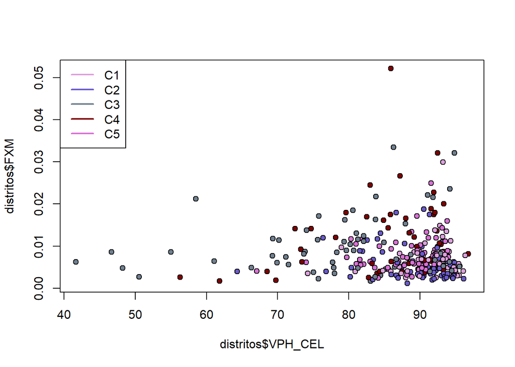

```r
plot(distritos$VPH_CEL, distritos$FXM, pch=21, bg=c('#DDA0DD', "#6A5ACD", "#708090", '#800000','#DA70D6')[unclass(distritos$CIRCUNSCRIPCIONES)])

legend('topleft', legend = c('C1', "C2", "C3", 'C4','C5'),
       lwd = 2, col=c('#DDA0DD', "#6A5ACD", "#708090", '#800000','#DA70D6'))
```

en el cual podemos ver que, cuando el porcentaje es menor que 55% (apróx) en teléfonos por hogar, el porcentaje de votos por FXM corresponde exclusivamente a la circunscripción 3.

Continuamos con `P15YM_ANSEIN` contra FXM

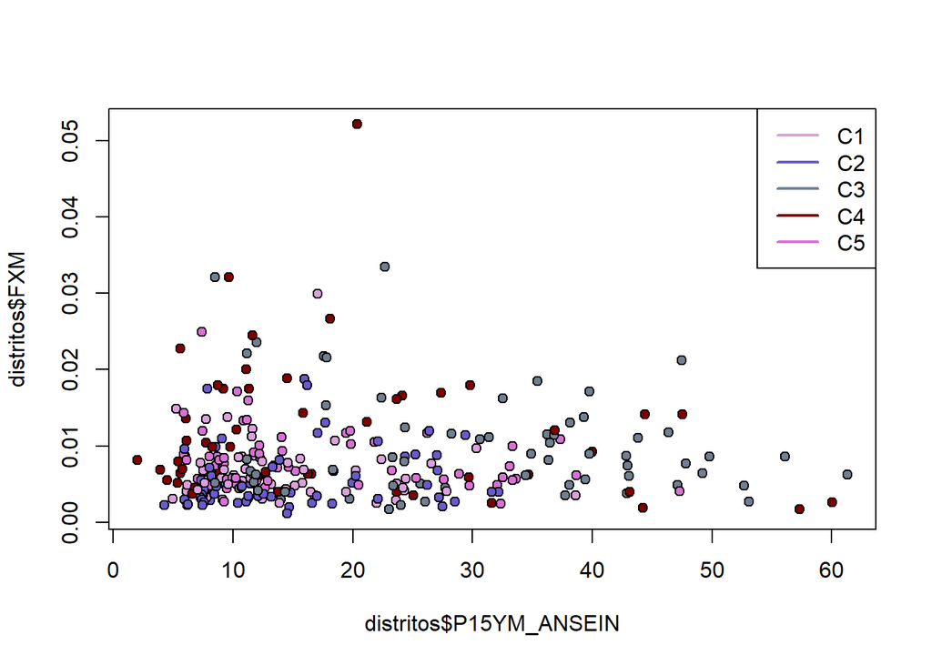

```r
plot(distritos$P15YM_ANSEIN, distritos$FXM, pch=21, bg=c('#DDA0DD', "#6A5ACD", "#708090", '#800000','#DA70D6')[unclass(distritos$CIRCUNSCRIPCIONES)])

legend('topright', legend = c('C1', "C2", "C3", 'C4','C5'),
       lwd = 2, col=c('#DDA0DD', "#6A5ACD", "#708090", '#800000','#DA70D6'))
```

del cual, a partir de un porcentaje de 50% en `P15YM_ANSEIN` tenemos que los votos por FXM fueron de las circunscripciones 3 y 4. También se puede decir que hubo una concentración importante de votos en las diversas circunscripciones entre el 0 y 20% de población de 15 años y más analfabeta.

### Ejercicio 4

1. Realiza un análisis similar el hecho anteriormente con el resto de las variables (`VPH_EXCSA`, `PSINDER` y `HOGJEF_F`) contra FXM.
2. Realiza un análisis similar el hecho anteriormente con las cinco variables respectivas contra JHH.